# Part I - (Loan Data from Prosper)

## Introduction

The dataset used in this project is popularly known as "Loan Data from Prosper". This data consists of 113,937 loan records of individuals. There are 81 features describing the loan data. The most important features are extracted for the purpose of this project.

## Preliminary Wrangling

```python
# import all packages and set plots to be embedded inline
import numpy as np
import pandas as pd
import matplotlib.pyplot as plt
import seaborn as sns

%matplotlib inline
```

```python
#loading the dataset into a pandas dataframe
loan_data = pd.read_csv('prosperLoanData.csv')
loan_data.head()
```

|  | ListingKey | ListingNumber | ListingCreationDate | CreditGrade | Term | LoanStatus | ClosedDate | BorrowerAPR | BorrowerRate | LenderYield | ... | LP_ServiceFees | LP_CollectionFees | LP_GrossPrincipalLoss | LP_NetPrincipalLoss | LP_NonPrincipalRecoverypayments | PercentFunded | Recommendations | InvestmentFromFriendsCount | InvestmentFromFriendsAmount | Investors |
| --- | --- | --- | --- | --- | --- | --- | --- | --- | --- | --- | --- | --- | --- | --- | --- | --- | --- | --- | --- | --- | --- |
| 0 | 1021339766868145413AB3B | 193129 | 2007-08-26 19:09:29.263000000 | C | 36 | Completed | 2009-08-14 00:00:00 | 0.16516 | 0.1580 | 0.1380 | ... | -133.18 | 0.0 | 0.0 | 0.0 | 0.0 | 1.0 | 0 | 0 | 0.0 | 258 |
| 1 | 10273602499503308B223C1 | 1209647 | 2014-02-27 08:28:07.900000000 | NaN | 36 | Current | NaN | 0.12016 | 0.0920 | 0.0820 | ... | 0.00 | 0.0 | 0.0 | 0.0 | 0.0 | 1.0 | 0 | 0 | 0.0 | 1 |
| 2 | 0EE9337825851032864889A | 81716 | 2007-01-05 15:00:47.090000000 | HR | 36 | Completed | 2009-12-17 00:00:00 | 0.28269 | 0.2750 | 0.2400 | ... | -24.20 | 0.0 | 0.0 | 0.0 | 0.0 | 1.0 | 0 | 0 | 0.0 | 41 |
| 3 | 0EF5356002482715299901A | 658116 | 2012-10-22 11:02:35.010000000 | NaN | 36 | Current | NaN | 0.12528 | 0.0974 | 0.0874 | ... | -108.01 | 0.0 | 0.0 | 0.0 | 0.0 | 1.0 | 0 | 0 | 0.0 | 158 |
| 4 | 0F023589499656230C5E3E2 | 909464 | 2013-09-14 18:38:39.097000000 | NaN | 36 | Current | NaN | 0.24614 | 0.2085 | 0.1985 | ... | -60.27 | 0.0 | 0.0 | 0.0 | 0.0 | 1.0 | 0 | 0 | 0.0 | 20 |

5 rows × 81 columns

```python
#getting the column names
loan_data.columns
```

```
Index(['ListingKey', 'ListingNumber', 'ListingCreationDate', 'CreditGrade',
       'Term', 'LoanStatus', 'ClosedDate', 'BorrowerAPR', 'BorrowerRate',
       'LenderYield', 'EstimatedEffectiveYield', 'EstimatedLoss',
       'EstimatedReturn', 'ProsperRating (numeric)', 'ProsperRating (Alpha)',
       'ProsperScore', 'ListingCategory (numeric)', 'BorrowerState',
       'Occupation', 'EmploymentStatus', 'EmploymentStatusDuration',
       'IsBorrowerHomeowner', 'CurrentlyInGroup', 'GroupKey',
       'DateCreditPulled', 'CreditScoreRangeLower', 'CreditScoreRangeUpper',
       'FirstRecordedCreditLine', 'CurrentCreditLines', 'OpenCreditLines',
       'TotalCreditLinespast7years', 'OpenRevolvingAccounts',
       'OpenRevolvingMonthlyPayment', 'InquiriesLast6Months', 'TotalInquiries',
       'CurrentDelinquencies', 'AmountDelinquent', 'DelinquenciesLast7Years',
       'PublicRecordsLast10Years', 'PublicRecordsLast12Months',
       'RevolvingCreditBalance', 'BankcardUtilization',
       'AvailableBankcardCredit', 'TotalTrades',
       'TradesNeverDelinquent (percentage)', 'TradesOpenedLast6Months',
       'DebtToIncomeRatio', 'IncomeRange', 'IncomeVerifiable',
       'StatedMonthlyIncome', 'LoanKey', 'TotalProsperLoans',
       'TotalProsperPaymentsBilled', 'OnTimeProsperPayments',
       'ProsperPaymentsLessThanOneMonthLate',
       'ProsperPaymentsOneMonthPlusLate', 'ProsperPrincipalBorrowed',
       'ProsperPrincipalOutstanding', 'ScorexChangeAtTimeOfListing',
       'LoanCurrentDaysDelinquent', 'LoanFirstDefaultedCycleNumber',
       'LoanMonthsSinceOrigination', 'LoanNumber', 'LoanOriginalAmount',
       'LoanOriginationDate', 'LoanOriginationQuarter', 'MemberKey',
       'MonthlyLoanPayment', 'LP_CustomerPayments',
       'LP_CustomerPrincipalPayments', 'LP_InterestandFees', 'LP_ServiceFees',
       'LP_CollectionFees', 'LP_GrossPrincipalLoss', 'LP_NetPrincipalLoss',
       'LP_NonPrincipalRecoverypayments', 'PercentFunded', 'Recommendations',
       'InvestmentFromFriendsCount', 'InvestmentFromFriendsAmount',
       'Investors'],
      dtype='object')
```

```python
#removing unnecessary columns or features
loan_data.drop(['ListingKey', 'ListingNumber', 'ListingCreationDate', 'CreditGrade',
       'ClosedDate',
       'LenderYield', 'EstimatedEffectiveYield', 'EstimatedLoss',
       'EstimatedReturn', 'ProsperRating (Alpha)',
       'ListingCategory (numeric)', 'BorrowerState',
        'EmploymentStatus', 'EmploymentStatusDuration',
       'IsBorrowerHomeowner', 'CurrentlyInGroup', 'GroupKey',
       'DateCreditPulled', 'CreditScoreRangeLower', 'CreditScoreRangeUpper',
       'FirstRecordedCreditLine', 'CurrentCreditLines', 'OpenCreditLines',
       'TotalCreditLinespast7years', 'OpenRevolvingAccounts',
       'OpenRevolvingMonthlyPayment', 'InquiriesLast6Months', 'TotalInquiries',
       'CurrentDelinquencies', 'AmountDelinquent', 'DelinquenciesLast7Years',
       'PublicRecordsLast10Years', 'PublicRecordsLast12Months',
       'RevolvingCreditBalance', 'BankcardUtilization',
       'AvailableBankcardCredit', 'TotalTrades',
       'TradesNeverDelinquent (percentage)', 'TradesOpenedLast6Months',
       'DebtToIncomeRatio', 'IncomeVerifiable',
       'StatedMonthlyIncome', 'LoanKey', 'TotalProsperLoans',
       'TotalProsperPaymentsBilled', 'OnTimeProsperPayments',
       'ProsperPaymentsLessThanOneMonthLate',
       'ProsperPaymentsOneMonthPlusLate', 'ProsperPrincipalBorrowed',
       'ProsperPrincipalOutstanding', 'ScorexChangeAtTimeOfListing',
       'LoanCurrentDaysDelinquent', 'LoanFirstDefaultedCycleNumber',
       'LoanMonthsSinceOrigination', 'LoanNumber',
       'LoanOriginationDate', 'LoanOriginationQuarter', 'MemberKey',
       'MonthlyLoanPayment', 'LP_CustomerPayments',
       'LP_CustomerPrincipalPayments', 'LP_InterestandFees', 'LP_ServiceFees',
       'LP_CollectionFees', 'LP_GrossPrincipalLoss', 'LP_NetPrincipalLoss',
       'LP_NonPrincipalRecoverypayments', 'PercentFunded',
       'InvestmentFromFriendsCount', 'InvestmentFromFriendsAmount',
       'Investors'], axis = 1, inplace=True)
```

```python
#looking at the dataframe to confirm the removal
loan_data.head()
```

|  | Term | LoanStatus | BorrowerAPR | BorrowerRate | ProsperRating (numeric) | ProsperScore | Occupation | IncomeRange | LoanOriginalAmount | Recommendations |
| --- | --- | --- | --- | --- | --- | --- | --- | --- | --- | --- |
| 0 | 36 | Completed | 0.16516 | 0.1580 | NaN | NaN | Other | $25,000-49,999 | 9425 | 0 |
| 1 | 36 | Current | 0.12016 | 0.0920 | 6.0 | 7.0 | Professional | $50,000-74,999 | 10000 | 0 |
| 2 | 36 | Completed | 0.28269 | 0.2750 | NaN | NaN | Other | Not displayed | 3001 | 0 |
| 3 | 36 | Current | 0.12528 | 0.0974 | 6.0 | 9.0 | Skilled Labor | $25,000-49,999 | 10000 | 0 |
| 4 | 36 | Current | 0.24614 | 0.2085 | 3.0 | 4.0 | Executive | $100,000+ | 15000 | 0 |

```python
#changing the name of the dataframe for easy handling
df = loan_data
df
```

|  | Term | LoanStatus | BorrowerAPR | BorrowerRate | ProsperRating (numeric) | ProsperScore | Occupation | IncomeRange | LoanOriginalAmount | Recommendations |
| --- | --- | --- | --- | --- | --- | --- | --- | --- | --- | --- |
| 0 | 36 | Completed | 0.16516 | 0.1580 | NaN | NaN | Other | $25,000-49,999 | 9425 | 0 |
| 1 | 36 | Current | 0.12016 | 0.0920 | 6.0 | 7.0 | Professional | $50,000-74,999 | 10000 | 0 |
| 2 | 36 | Completed | 0.28269 | 0.2750 | NaN | NaN | Other | Not displayed | 3001 | 0 |
| 3 | 36 | Current | 0.12528 | 0.0974 | 6.0 | 9.0 | Skilled Labor | $25,000-49,999 | 10000 | 0 |
| 4 | 36 | Current | 0.24614 | 0.2085 | 3.0 | 4.0 | Executive | $100,000+ | 15000 | 0 |
| ... | ... | ... | ... | ... | ... | ... | ... | ... | ... | ... |
| 113932 | 36 | Current | 0.22354 | 0.1864 | 4.0 | 5.0 | Food Service Management | $50,000-74,999 | 10000 | 0 |
| 113933 | 36 | FinalPaymentInProgress | 0.13220 | 0.1110 | 6.0 | 8.0 | Professional | $75,000-99,999 | 2000 | 0 |
| 113934 | 60 | Current | 0.23984 | 0.2150 | 3.0 | 3.0 | Other | $25,000-49,999 | 10000 | 0 |
| 113935 | 60 | Completed | 0.28408 | 0.2605 | 4.0 | 5.0 | Food Service | $25,000-49,999 | 15000 | 0 |
| 113936 | 36 | Current | 0.13189 | 0.1039 | 6.0 | 7.0 | Professor | $50,000-74,999 | 2000 | 0 |

113937 rows × 10 columns

```python
#getting some information about the data
df.info()
```

```
<class 'pandas.core.frame.DataFrame'>
RangeIndex: 113937 entries, 0 to 113936
Data columns (total 10 columns):
 #   Column                   Non-Null Count   Dtype
---  ------                   --------------   -----
 0   Term                     113937 non-null  int64
 1   LoanStatus               113937 non-null  object
 2   BorrowerAPR              113912 non-null  float64
 3   BorrowerRate             113937 non-null  float64
 4   ProsperRating (numeric)  84853 non-null   float64
 5   ProsperScore             84853 non-null   float64
 6   Occupation               110349 non-null  object
 7   IncomeRange              113937 non-null  object
 8   LoanOriginalAmount       113937 non-null  int64
 9   Recommendations          113937 non-null  int64
dtypes: float64(4), int64(3), object(3)
memory usage: 8.7+ MB
```

Some columns have null values such as prosperrating, prosper score etc. It is better to remove the null rows for further analysis.

```python
#dropping all rows with null values
df.dropna(inplace=True)
```

```python
#getting the summary statistics
df.describe()
```

|  | Term | BorrowerAPR | BorrowerRate | ProsperRating (numeric) | ProsperScore | LoanOriginalAmount | Recommendations |
| --- | --- | --- | --- | --- | --- | --- | --- |
| count | 83520.00000 | 83520.000000 | 83520.000000 | 83520.000000 | 83520.000000 | 83520.000000 | 83520.000000 |
| mean | 42.51523 | 0.226863 | 0.196257 | 4.071839 | 5.964966 | 9103.743427 | 0.017816 |
| std | 11.66907 | 0.080115 | 0.074807 | 1.675900 | 2.375933 | 6300.856735 | 0.189383 |
| min | 12.00000 | 0.045830 | 0.040000 | 1.000000 | 1.000000 | 1000.000000 | 0.000000 |
| 25% | 36.00000 | 0.163280 | 0.135900 | 3.000000 | 4.000000 | 4000.000000 | 0.000000 |
| 50% | 36.00000 | 0.219450 | 0.187500 | 4.000000 | 6.000000 | 7500.000000 | 0.000000 |
| 75% | 60.00000 | 0.292540 | 0.257400 | 5.000000 | 8.000000 | 14000.000000 | 0.000000 |
| max | 60.00000 | 0.423950 | 0.360000 | 7.000000 | 11.000000 | 35000.000000 | 19.000000 |

### What is the structure of your dataset?

> The original data consists of 113,937 records of loan described by 81 features. However, the 10 most important features have been selected for this project.

### What is/are the main feature(s) of interest in your dataset?

> My feature of interest is annual percentage rate (APR). I want to know the influence of the other 9 features on the APR.

### What features in the dataset do you think will help support your investigation into your feature(s) of interest?

> This can be done by exploring the relationship between APR and other 9 features such as term, propsperrating, prosperscore, etc.

## Univariate Exploration

#### Question - What is the distribution of the main variable (i.e., APR)?

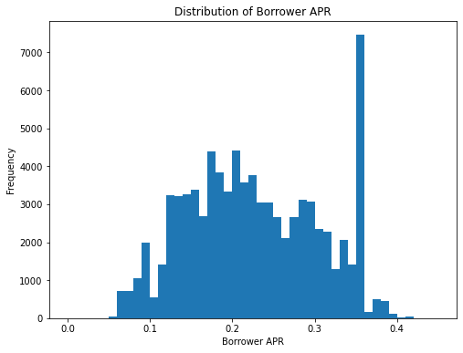

```python
###Visualization

bins = np.arange(0, df['BorrowerAPR'].max()+0.03, 0.01)
plt.figure(figsize = [8, 6])
plt.hist(data = df, x = 'BorrowerAPR', bins = bins)
plt.ylabel('Frequency')
plt.xlabel('Borrower APR')
plt.title('Distribution of Borrower APR');
```

#### Question - What is the distribution of the occupation of the borrowers?

```python
df['Occupation'].value_counts()
```

```
Other                          21317
Professional                   10542
Executive                       3468
Computer Programmer             3236
Teacher                         2888
                               ...
Judge                             22
Student - College Freshman        17
Student - College Sophomore       16
Student - Community College       10
Student - Technical School         2
Name: Occupation, Length: 67, dtype: int64
```

This shows that there are 67 occupation types in the data. I will only be showing the top 30 for easy visualization.

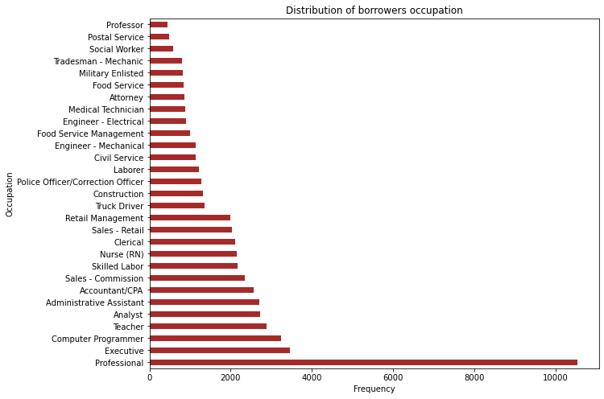

```python
#visualisation
plt.figure(figsize=(10,8))
occ = df['Occupation'].value_counts().nlargest(30)
del occ['Other'] #remove "other" from the list
occ.plot(kind = 'barh', color = 'brown')
plt.xlabel('Frequency')
plt.ylabel('Occupation')
plt.title('Distribution of borrowers occupation')
plt.show();
```

Compare to other occupations, professional, computer programmer, executive, teacher, and administrative assistant are most likely to apply for loans.

### Question - What is the income range of the borrowers?

```python
df['IncomeRange'].value_counts()
```

```
$50,000-74,999    25293
$25,000-49,999    23574
$100,000+         15166
$75,000-99,999    14401
$1-24,999          4392
Not employed        649
$0                   45
Name: IncomeRange, dtype: int64
```

```python
#reorder the incomerange column from low income to high income
income_range = ['Not employed', '$0', '$1-24,999', '$25,000-49,999', '$50,000-74,999', '$75,000-99,999', '$100,000+']
income_class = pd.api.types.CategoricalDtype(ordered=True, categories=income_range)
df['IncomeRange'] = df['IncomeRange'].astype(income_class)
```

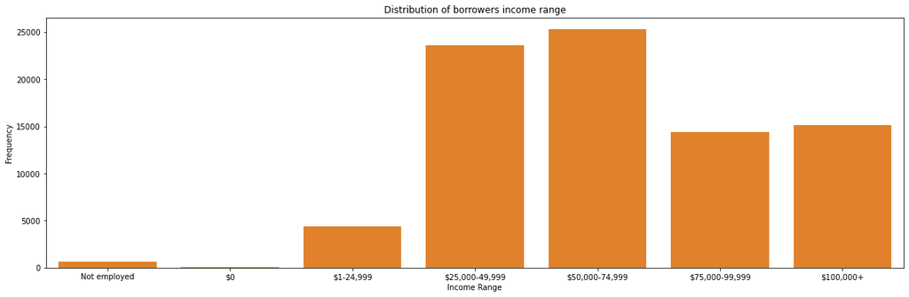

```python
#visualisation
plt.figure(figsize=(20,6))
color = sns.color_palette()[1]
sns.countplot(data = df, x='IncomeRange', color=color)
plt.ylabel('Frequency')
plt.xlabel('Income Range')
plt.title('Distribution of borrowers income range');
```

### Question - What is the distribution of the original loan amount?

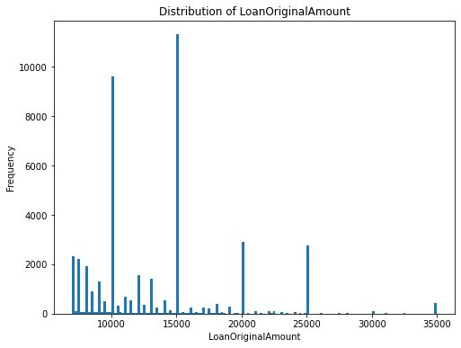

```python
###Visualization

bins = np.arange(7000, df['LoanOriginalAmount'].max()+200, 200)
plt.figure(figsize = [8, 6])
plt.hist(data = df, x = 'LoanOriginalAmount', bins = bins)
plt.ylabel('Frequency')
plt.xlabel('LoanOriginalAmount')
plt.title('Distribution of LoanOriginalAmount');
```

It is noticed that the frequency at 15,000 is the highest followed by 10,000. Very few people request for 30,000 and above loan.

### Question - Which term has the highest loan records and what is the dominant prosper rating?

```python
df['ProsperRating (numeric)'].value_counts()
```

```
4.0    17956
5.0    15329
6.0    14337
3.0    14081
2.0     9621
1.0     6878
7.0     5318
Name: ProsperRating (numeric), dtype: int64
```

```python
#rename some of the columns for easy handling
df.rename(columns ={'BorrowerAPR' : 'APR', 'BorrowerRate': 'InterestRate', 'ProsperRating (numeric)' :'ProsperRating', 'LoanOriginalAmount': 'LoanAmount'}, inplace=True)
df.head()
```

|  | Term | LoanStatus | APR | InterestRate | ProsperRating | ProsperScore | Occupation | IncomeRange | LoanAmount | Recommendations |
| --- | --- | --- | --- | --- | --- | --- | --- | --- | --- | --- |
| 1 | 36 | Current | 0.12016 | 0.0920 | 6.0 | 7.0 | Professional | $50,000-74,999 | 10000 | 0 |
| 3 | 36 | Current | 0.12528 | 0.0974 | 6.0 | 9.0 | Skilled Labor | $25,000-49,999 | 10000 | 0 |
| 4 | 36 | Current | 0.24614 | 0.2085 | 3.0 | 4.0 | Executive | $100,000+ | 15000 | 0 |
| 5 | 60 | Current | 0.15425 | 0.1314 | 5.0 | 10.0 | Professional | $100,000+ | 15000 | 0 |
| 6 | 36 | Current | 0.31032 | 0.2712 | 2.0 | 2.0 | Sales - Retail | $25,000-49,999 | 3000 | 0 |

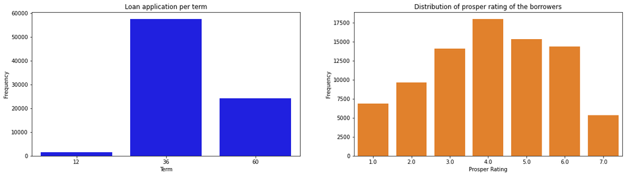

```python
#visualization
plt.figure(figsize = [20, 5])

plt.subplot(1, 2, 1)
sns.countplot(data = df, x='Term', color='b')
plt.ylabel('Frequency')
plt.xlabel('Term')
plt.title('Loan application per term');

plt.subplot(1, 2, 2)
color = sns.color_palette()[1]
sns.countplot(data = df, x='ProsperRating', color=color)
plt.ylabel('Frequency')
plt.xlabel('Prosper Rating')
plt.title('Distribution of prosper rating of the borrowers');
```

#### Observation

The results show that most of the loans were made for 36 months and the prosper ratings of the borrowers follows a normal distribution.

```python
df['LoanStatus'].value_counts()
```

```
Current                   55272
Completed                 19651
Chargedoff                 5336
Defaulted                  1005
Past Due (1-15 days)        798
Past Due (31-60 days)       358
Past Due (61-90 days)       313
Past Due (91-120 days)      304
Past Due (16-30 days)       264
FinalPaymentInProgress      203
Past Due (>120 days)         16
Name: LoanStatus, dtype: int64
```

### Discuss the distribution(s) of your variable(s) of interest. Were there any unusual points? Did you need to perform any transformations?

> The distribution of the APR variable, which s the main variable of interest, appears to be multimodal, as it has different peak values. There was no need for transformation, as most of the values lie between 0 to 0.4, which can be easily visualized.

### Of the features you investigated, were there any unusual distributions? Did you perform any operations on the data to tidy, adjust, or change the form of the data? If so, why did you do this?

> There was no need for performing transformation. The distributions were easily visualized. The names of some columns were changed to facilitate easy handling.